# AMPBA 2022W Batch 17

#### * The relationship between day and orders

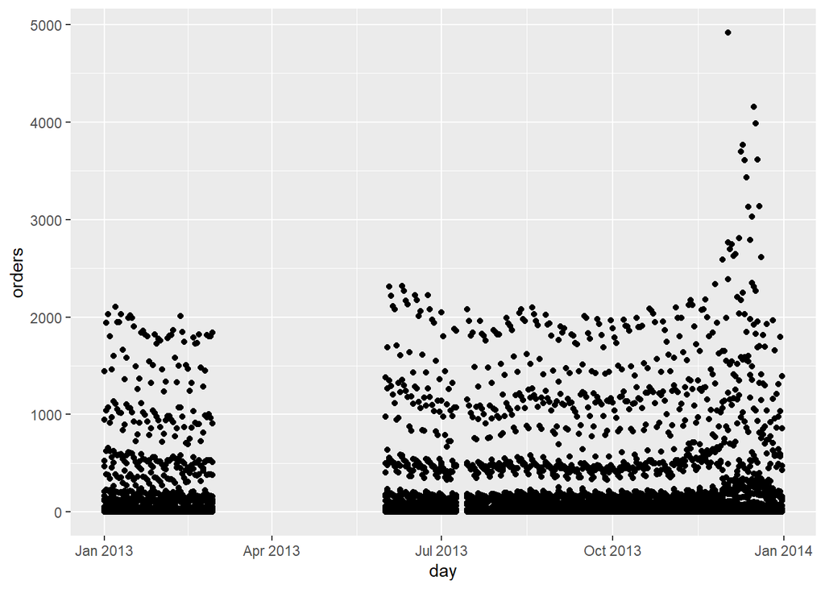

```r
     ggplot(aes(x=day,y=orders),data=prob.assignment.dataset)+geom_point(alpha=1)
```

#### *Analysis

There are no orders in the month of Apr 2013 and High visits on the oct 2013 to Jan 2014.

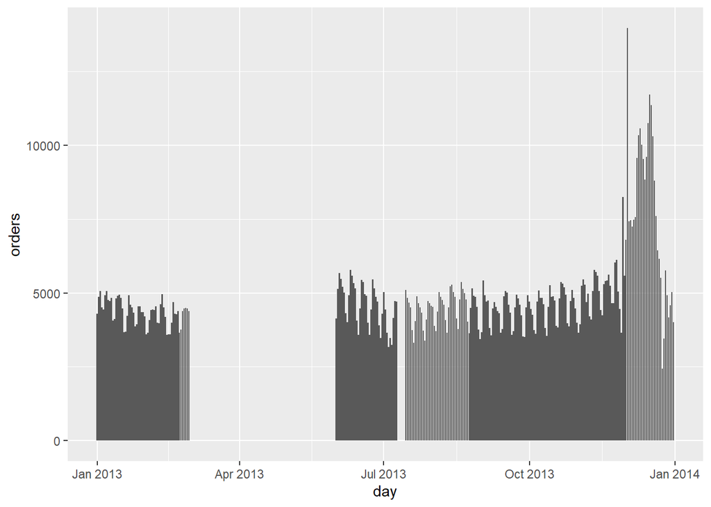

```r
     ggplot(aes(x=day,y=orders),data=prob.assignment.dataset)+geom_bar(stat="identity")
```

#### *Analysis

There are no orders in the month of Apr 2013 and High visits on the oct 2013 to Jan 2014.

#### * The relationship between day and visits

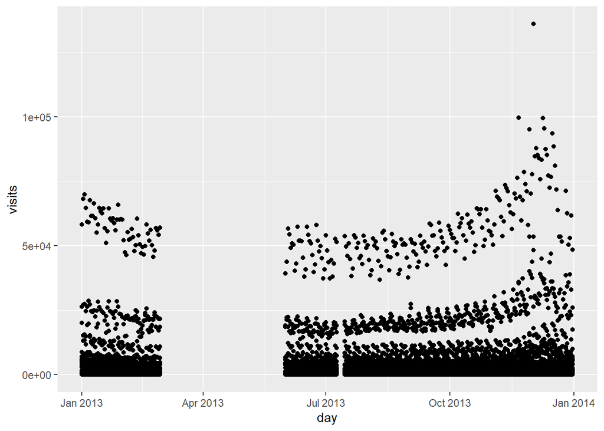

```r
     ggplot(aes(x=day,y=visits),data=prob.assignment.dataset)+geom_point(alpha=1)
```

#### *Analysis

There are no visits in the month of Apr 2013 and High visits on the oct 2013 to Jan 2014.

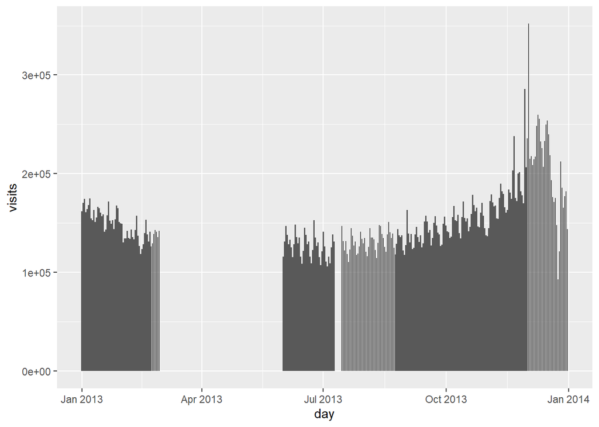

```r
     ggplot(aes(x=day,y=visits),data=prob.assignment.dataset)+geom_bar(stat="identity")
```

#### *Analysis

There are no visits in the month of Apr 2013 and High visits on the oct 2013 to Jan 2014.

#### * The relationship between orders and gross_sales

```r
    library('dplyr')
    orders.groups <- group_by(na.omit(prob.assignment.dataset),orders)
    conditional_mean_by_orders <- summarise(orders.groups, gross_sales_mean = mean(gross_sales),
                                     gross_sales_median = median(gross_sales), n=n())
    head(conditional_mean_by_orders)
```

```
## # A tibble: 6 x 4
##   orders gross_sales_mean gross_sales_median     n
##    <dbl>            <dbl>              <dbl> <int>
## 1      0             30.4                21   2255
## 2      1            129.                 99   1510
## 3      2            362.                311    633
## 4      3            598.                537    468
## 5      4            778.                648.   352
## 6      5           1074.                785    317
```

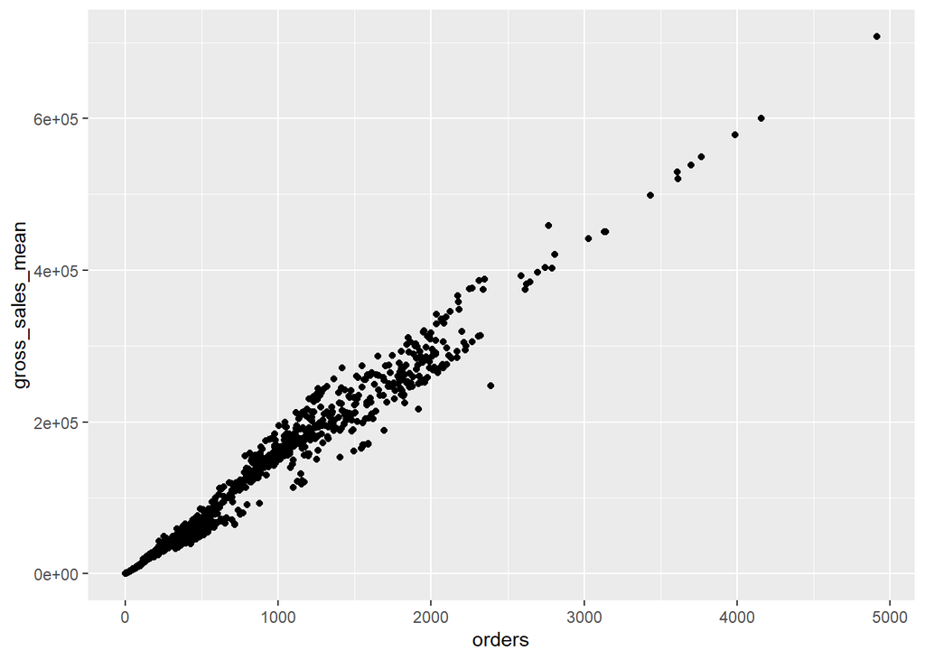

```r
    ggplot(aes(orders,gross_sales_mean,na.rm=TRUE),data=conditional_mean_by_orders)+geom_point()
```

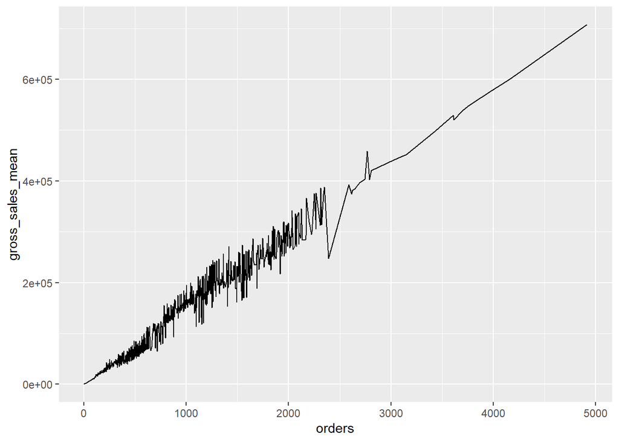

```r
    ggplot(aes(orders,gross_sales_mean,na.rm=TRUE),data=conditional_mean_by_orders)+geom_line()
```

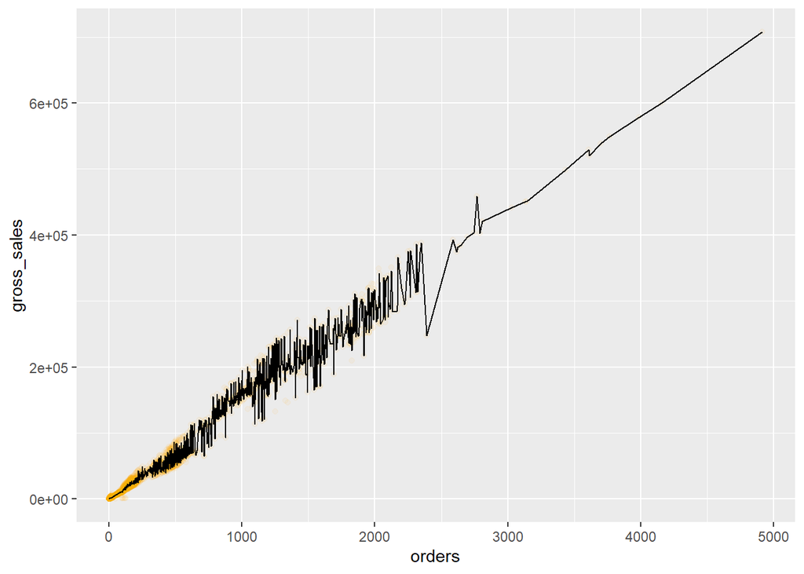

```r
    ggplot(aes(x=orders,y=gross_sales),data=prob.assignment.dataset)+geom_point(alpha=1/20,color='orange')+stat_summary(geom = "line", fun = "mean")
```

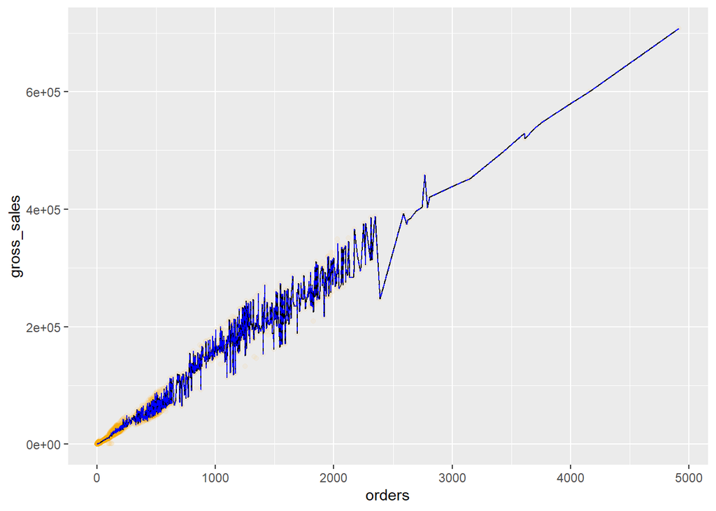

```r
    ggplot(aes(x=orders,y=gross_sales),data=prob.assignment.dataset)+geom_point(alpha=1/20,color='orange')+stat_summary(geom = "line", fun = "mean")+
    stat_summary(geom = "line", fun = "median",linetype=2,color='blue')
```

```r
    cor.test(prob.assignment.dataset$orders, prob.assignment.dataset$gross_sales, method='pearson')
```

```
##
##  Pearson's product-moment correlation
##
## data:  prob.assignment.dataset$orders and prob.assignment.dataset$gross_sales
## t = 826.16, df = 11483, p-value < 2.2e-16
## alternative hypothesis: true correlation is not equal to 0
## 95 percent confidence interval:
##  0.9913846 0.9919900
## sample estimates:
##       cor
## 0.9916928
```

```r
    with(subset(prob.assignment.dataset,orders<2000),cor.test(orders,gross_sales))
```

```
##
##  Pearson's product-moment correlation
##
## data:  orders and gross_sales
## t = 740.6, df = 11416, p-value < 2.2e-16
## alternative hypothesis: true correlation is not equal to 0
## 95 percent confidence interval:
##  0.9893721 0.9901203
## sample estimates:
##      cor
## 0.989753
```

#### * The relationship between distinct_sessions and bounces

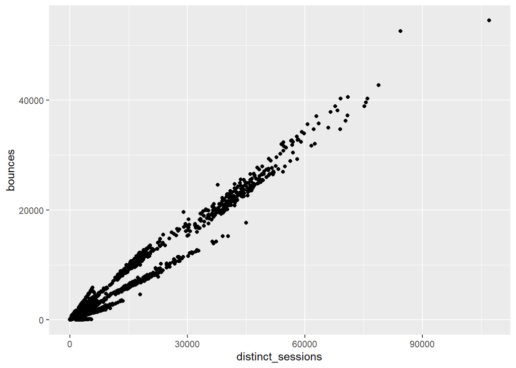

```r
     qplot(x=distinct_sessions,y=bounces,data=prob.assignment.dataset)
```

#### * The relationship between product_page_views and search_page_views

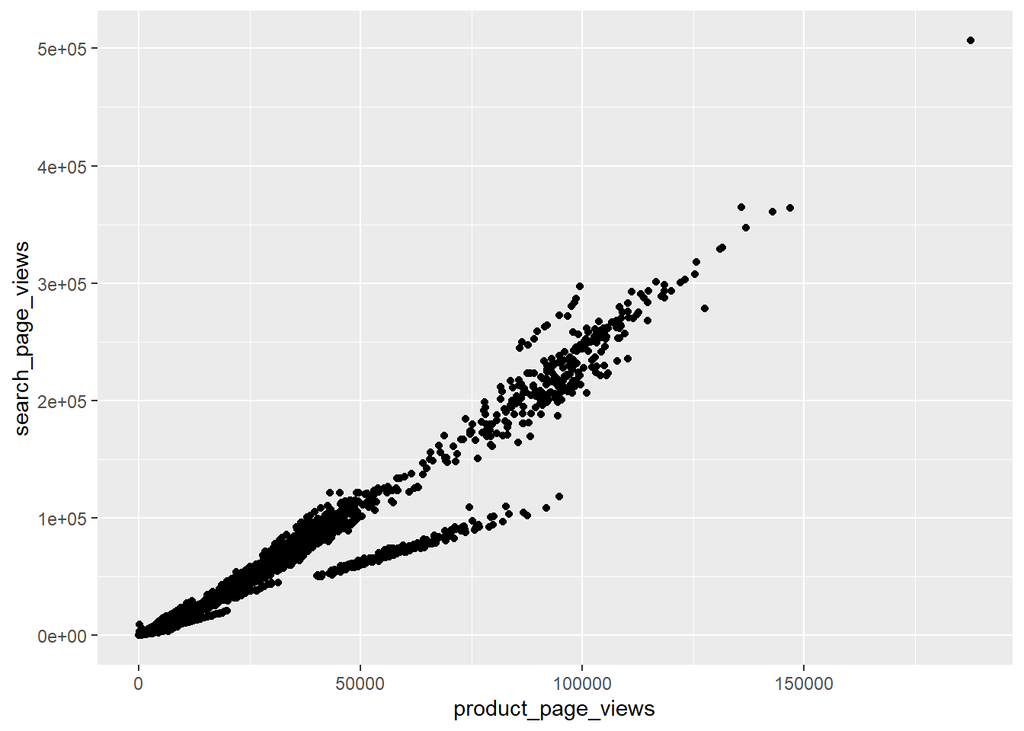

```r
    ggplot(aes(x=product_page_views,y=search_page_views),data=prob.assignment.dataset) +   geom_point()
```

```r
    cor.test(prob.assignment.dataset$product_page_views, prob.assignment.dataset$search_page_views)
```

```
##
##  Pearson's product-moment correlation
##
## data:  prob.assignment.dataset$product_page_views and prob.assignment.dataset$search_page_views
## t = 645.12, df = 21059, p-value < 2.2e-16
## alternative hypothesis: true correlation is not equal to 0
## 95 percent confidence interval:
##  0.9749618 0.9762629
## sample estimates:
##       cor
## 0.9756209
```

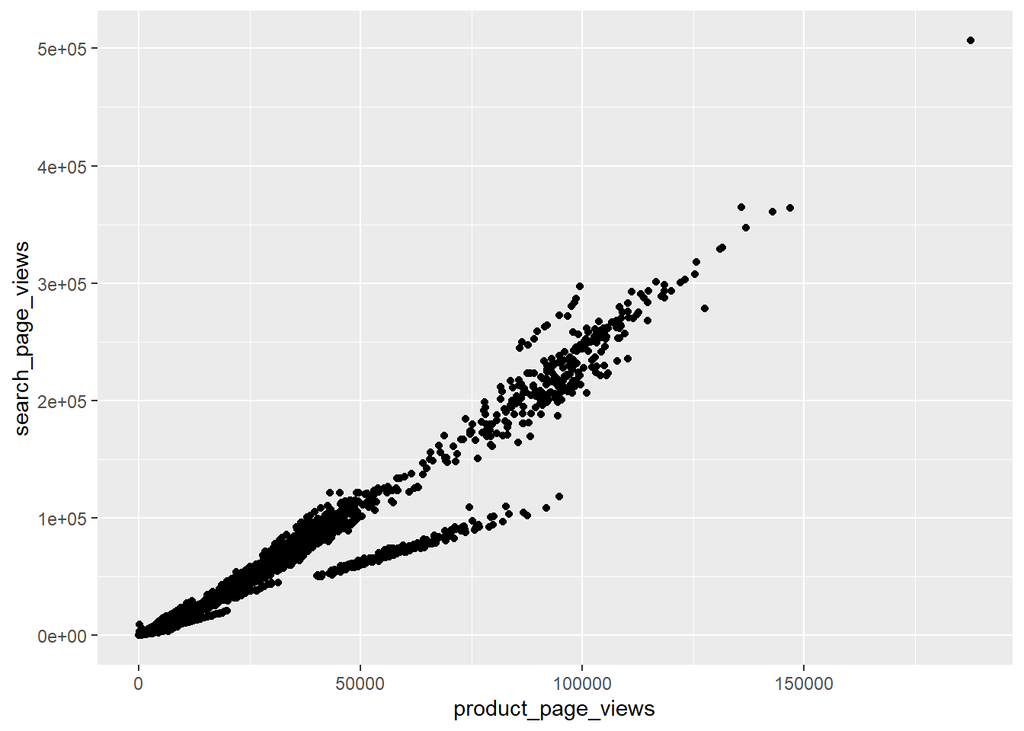

```r
  ggplot(aes(x=product_page_views,y=search_page_views),data=prob.assignment.dataset) + geom_point()
```

```r
    with(subset(prob.assignment.dataset,search_page_views<10),cor.test(product_page_views,search_page_views))
```

```
##
##  Pearson's product-moment correlation
##
## data:  product_page_views and search_page_views
## t = 35.069, df = 6768, p-value < 2.2e-16
## alternative hypothesis: true correlation is not equal to 0
## 95 percent confidence interval:
##  0.3717903 0.4121105
## sample estimates:
##       cor
## 0.3921387
```

```r
    cor.test(prob.assignment.dataset$product_page_views, prob.assignment.dataset$search_page_views)
```

```
##
##  Pearson's product-moment correlation
##
## data:  prob.assignment.dataset$product_page_views and prob.assignment.dataset$search_page_views
## t = 645.12, df = 21059, p-value < 2.2e-16
## alternative hypothesis: true correlation is not equal to 0
## 95 percent confidence interval:
##  0.9749618 0.9762629
## sample estimates:
##       cor
## 0.9756209
```